# Analisis exploratorio

# 3. Investigacion de variables cuantitativas

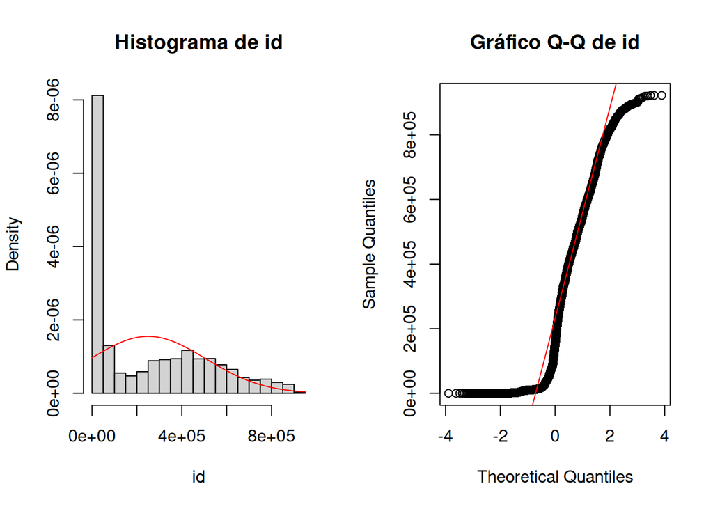

```
##
## === Análisis de Normalidad para id ===
## Test de Kolmogorov-Smirnov:
## D = 0.200786
## p-value = 0
## Asimetría: 0.6818543
## Curtosis: 2.209512
##
## Interpretación:
## La variable NO sigue una distribución normal (p < 0.05)
## ----------------------------------------
```

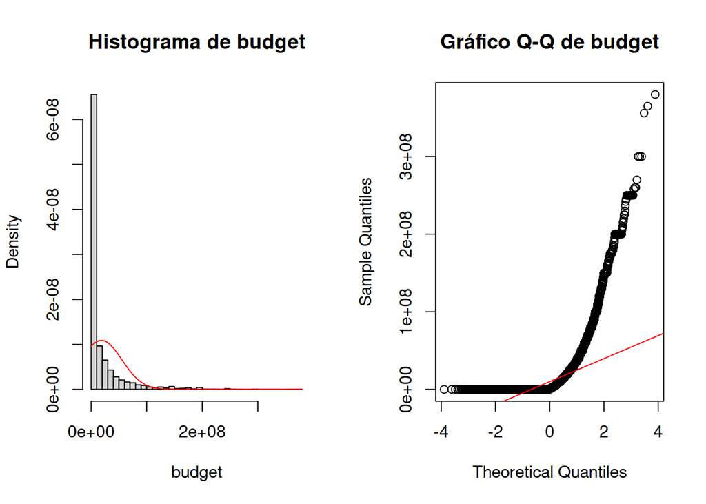

```
##
## === Análisis de Normalidad para budget ===
## Test de Kolmogorov-Smirnov:
## D = 0.3062508
## p-value = 0
## Asimetría: 3.244377
## Curtosis: 16.21103
##
## Interpretación:
## La variable NO sigue una distribución normal (p < 0.05)
## ----------------------------------------
```

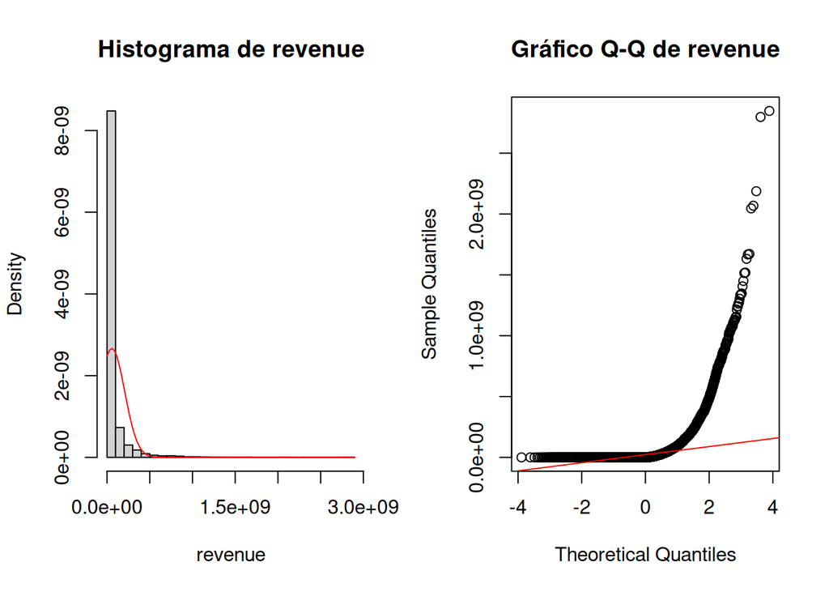

```
##
## === Análisis de Normalidad para revenue ===
## Test de Kolmogorov-Smirnov:
## D = 0.3522321
## p-value = 0
## Asimetría: 5.918969
## Curtosis: 58.90346
##
## Interpretación:
## La variable NO sigue una distribución normal (p < 0.05)
## ----------------------------------------
```

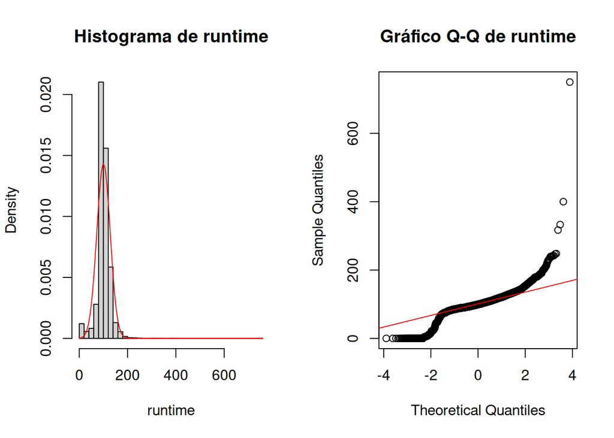

```
##
## === Análisis de Normalidad para runtime ===
## Test de Kolmogorov-Smirnov:
## D = 0.1440795
## p-value = 9.80453e-181
## Asimetría: 0.9718444
## Curtosis: 38.53637
##
## Interpretación:
## La variable NO sigue una distribución normal (p < 0.05)
## ----------------------------------------
```

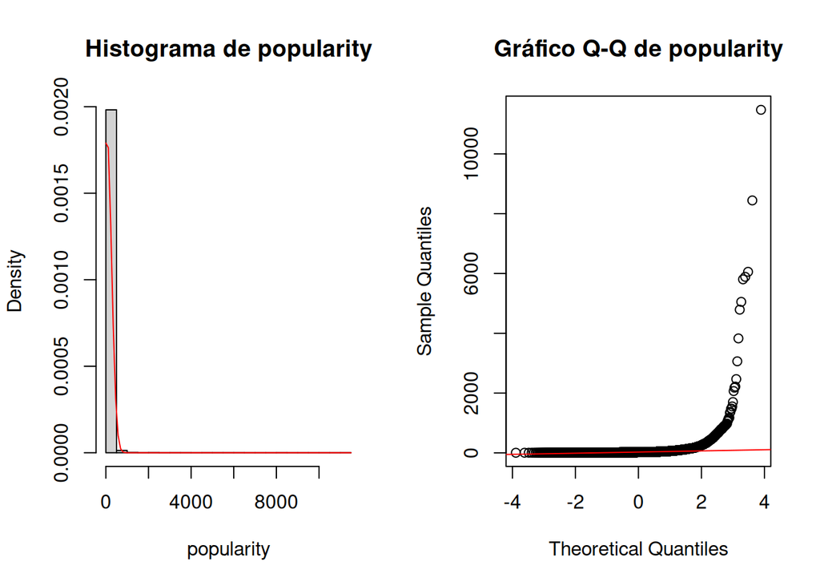

```
##
## === Análisis de Normalidad para popularity ===
## Test de Kolmogorov-Smirnov:
## D = 0.4173351
## p-value = 0
## Asimetría: 30.37438
## Curtosis: 1228.579
##
## Interpretación:
## La variable NO sigue una distribución normal (p < 0.05)
## ----------------------------------------
```

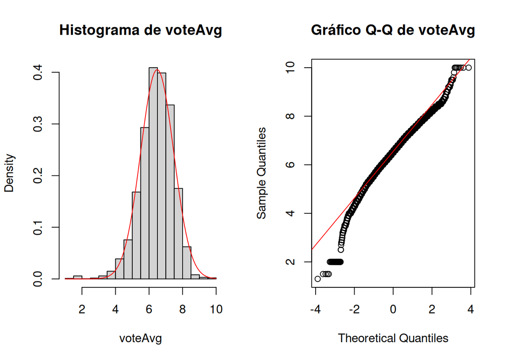

```
##
## === Análisis de Normalidad para voteAvg ===
## Test de Kolmogorov-Smirnov:
## D = 0.04590985
## p-value = 9.855071e-19
## Asimetría: -0.5777132
## Curtosis: 4.485723
##
## Interpretación:
## La variable NO sigue una distribución normal (p < 0.05)
## ----------------------------------------
```

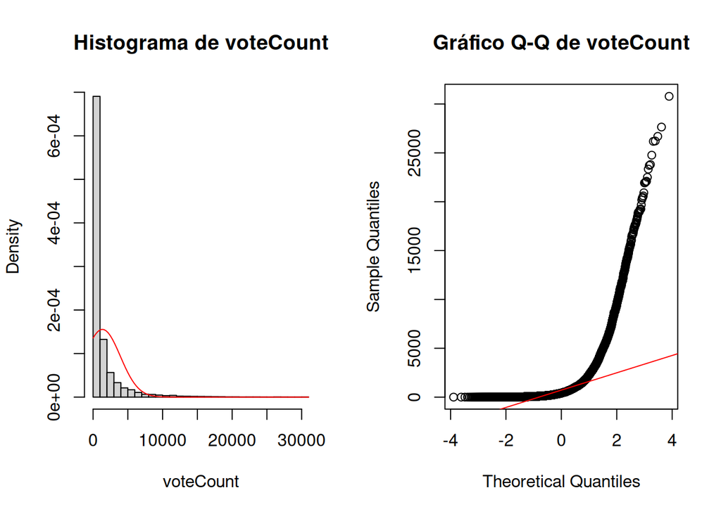

```
##
## === Análisis de Normalidad para voteCount ===
## Test de Kolmogorov-Smirnov:
## D = 0.3004455
## p-value = 0
## Asimetría: 4.146482
## Curtosis: 25.77017
##
## Interpretación:
## La variable NO sigue una distribución normal (p < 0.05)
## ----------------------------------------
```

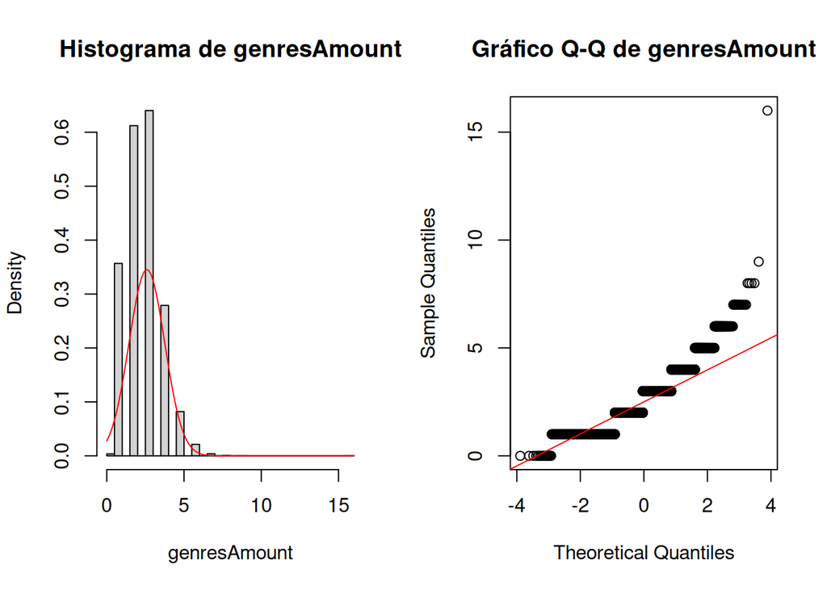

```
##
## === Análisis de Normalidad para genresAmount ===
## Test de Kolmogorov-Smirnov:
## D = 0.1835979
## p-value = 3.277002e-293
## Asimetría: 0.6913409
## Curtosis: 5.105845
##
## Interpretación:
## La variable NO sigue una distribución normal (p < 0.05)
## ----------------------------------------
```

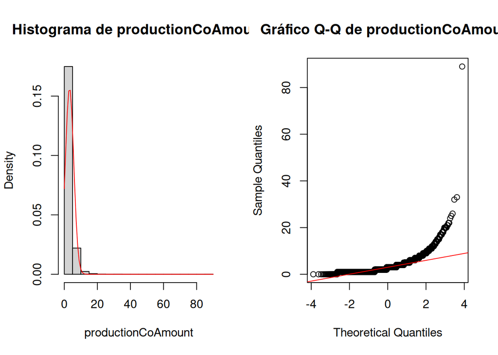

```
##
## === Análisis de Normalidad para productionCoAmount ===
## Test de Kolmogorov-Smirnov:
## D = 0.2004031
## p-value = 0
## Asimetría: 5.98768
## Curtosis: 143.3022
##
## Interpretación:
## La variable NO sigue una distribución normal (p < 0.05)
## ----------------------------------------
```

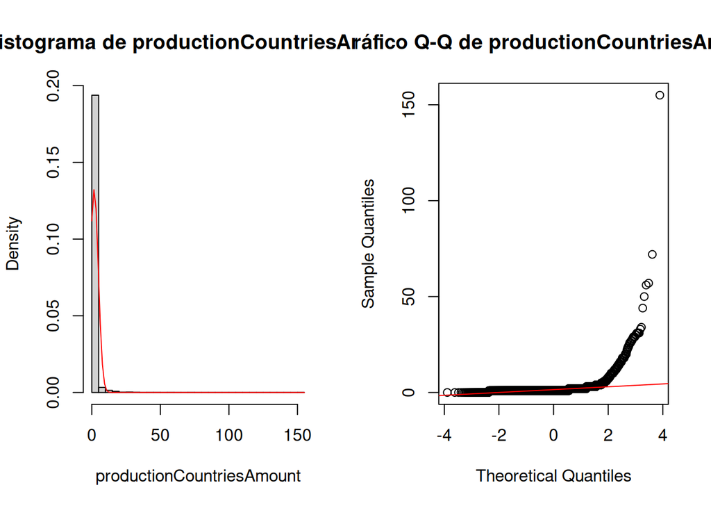

```
##
## === Análisis de Normalidad para productionCountriesAmount ===
## Test de Kolmogorov-Smirnov:
## D = 0.3926534
## p-value = 0
## Asimetría: 19.39132
## Curtosis: 754.3524
##
## Interpretación:
## La variable NO sigue una distribución normal (p < 0.05)
## ----------------------------------------
```

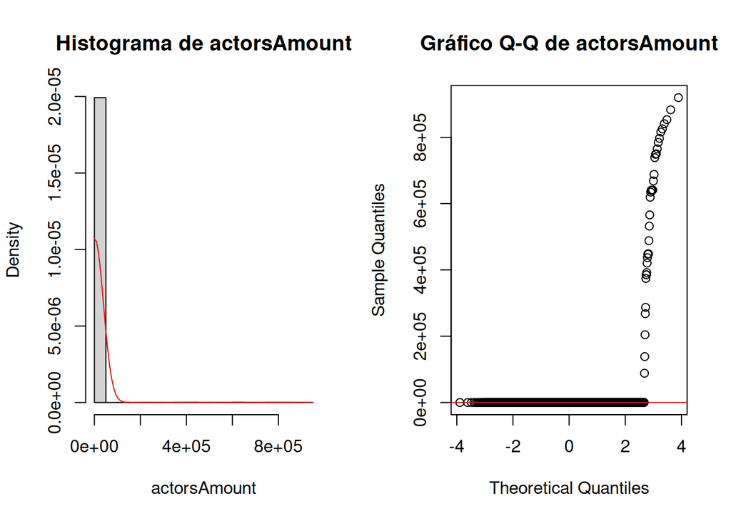

```
##
## === Análisis de Normalidad para actorsAmount ===
## Test de Kolmogorov-Smirnov:
## D = 0.5166885
## p-value = 0
## Asimetría: 18.8534
## Curtosis: 374.1707
##
## Interpretación:
## La variable NO sigue una distribución normal (p < 0.05)
## ----------------------------------------
```

```r
library(moments)
# Lista con las variables cuantitativas que identificamos en el summary
variables_cuantitativas <- c("id", "budget", "revenue", "runtime", "popularity",
                           "voteAvg", "voteCount", "genresAmount",
                           "productionCoAmount", "productionCountriesAmount",
                           "actorsAmount")

# Función para realizar pruebas de normalidad
analizar_normalidad <- function(variable) {
    # Test de Kolmogorov-Smirnov
    x <- movies[[variable]]
    x_clean <- x[!is.na(x)]  # Removing NA values

    # Calculo de media y desviacion estandar
    media <- mean(x_clean)
    desv <- sd(x_clean)

    # Test ks
    test_ks <- ks.test(x_clean, "pnorm", mean = media, sd = desv)

    asimetria <- skewness(x_clean)
    curtosis <- kurtosis(x_clean)

    # graficas
    par(mfrow = c(1, 2))

    # histograma
    hist(x_clean,
         main = paste("Histograma de", variable),
         xlab = variable,
         freq = FALSE,
         breaks = 30)
    curve(dnorm(x, mean = media, sd = desv),
          add = TRUE, col = "red")

    # qqplot
    qqnorm(x_clean,
           main = paste("Gráfico Q-Q de", variable))
    qqline(x_clean, col = "red")

    par(mfrow = c(1, 1))

    return(list(
        variable = variable,
        ks_test = test_ks,
        asimetria = asimetria,
        curtosis = curtosis
    ))
}

resultados <- list()
for(var in variables_cuantitativas) {
    resultados[[var]] <- analizar_normalidad(var)
    cat("\n=== Análisis de Normalidad para", var, "===\n")
    cat("Test de Kolmogorov-Smirnov:\n")
    cat("D =", resultados[[var]]$ks_test$statistic, "\n")
    cat("p-value =", resultados[[var]]$ks_test$p.value, "\n")
    cat("Asimetría:", resultados[[var]]$asimetria, "\n")
    cat("Curtosis:", resultados[[var]]$curtosis, "\n")
    cat("\nInterpretación:\n")
    if(resultados[[var]]$ks_test$p.value < 0.05) {
        cat("La variable NO sigue una distribución normal (p < 0.05)\n")
    } else {
        cat("La variable sigue una distribución normal (p >= 0.05)\n")
    }
    cat("----------------------------------------\n")
}
```

# 4.1 Películas con más presupuesto

A continuación se mostrarán las 10 películas con mayor presupuesto y algunos datos de importancia.

```r
cat("*** Top 10 Películas con mayor presupuesto ***\n")
```

```
## *** Top 10 Películas con mayor presupuesto ***
```

```r
top <- movies[order(movies$budget, decreasing=TRUE),]
top_10 <- head(top[,c("title", "budget", "revenue","releaseDate")], 10)
print(top_10)
```

```
##                                            title    budget    revenue
## 717  Pirates of the Caribbean: On Stranger Tides 380000000 1045713802
## 4711                     Avengers: Age of Ultron 365000000 1405403694
## 5953                           Avengers: Endgame 356000000 2797800564
## 164     Pirates of the Caribbean: At World's End 300000000  961000000
## 4954                              Justice League 300000000  657924295
## 5954                      Avengers: Infinity War 300000000 2046239637
## 608                             Superman Returns 270000000  391081192
## 3792                                     Tangled 260000000  592461732
## 7135                               The Lion King 260000000 1667635327
## 281                                 Spider-Man 3 258000000  890871626
##      releaseDate
## 717   2011-05-14
## 4711  2015-04-22
## 5953  2019-04-24
## 164   2007-05-19
## 4954  2017-11-15
## 5954  2018-04-25
## 608   2006-06-28
## 3792  2010-11-24
## 7135  2019-07-12
## 281   2007-05-01
```

# 4.3 Película con más votos

```r
cat("*** Película con más votos***")
```

```
## *** Película con más votos***
```

```r
topvot <- movies[order(movies$voteCount, decreasing=TRUE),]
topvot <- head(topvot[,c("title", "voteCount")], 1)
sprintf("%s es la película con más votos, con un total de %s",
        topvot$title, topvot$voteCount)
```

```
## [1] "Inception es la película con más votos, con un total de 30788"
```

# 4.5 Cantidad de películas por año

```r
cat("*** Cantidad de películas por año***")
```

```
## *** Cantidad de películas por año***
```

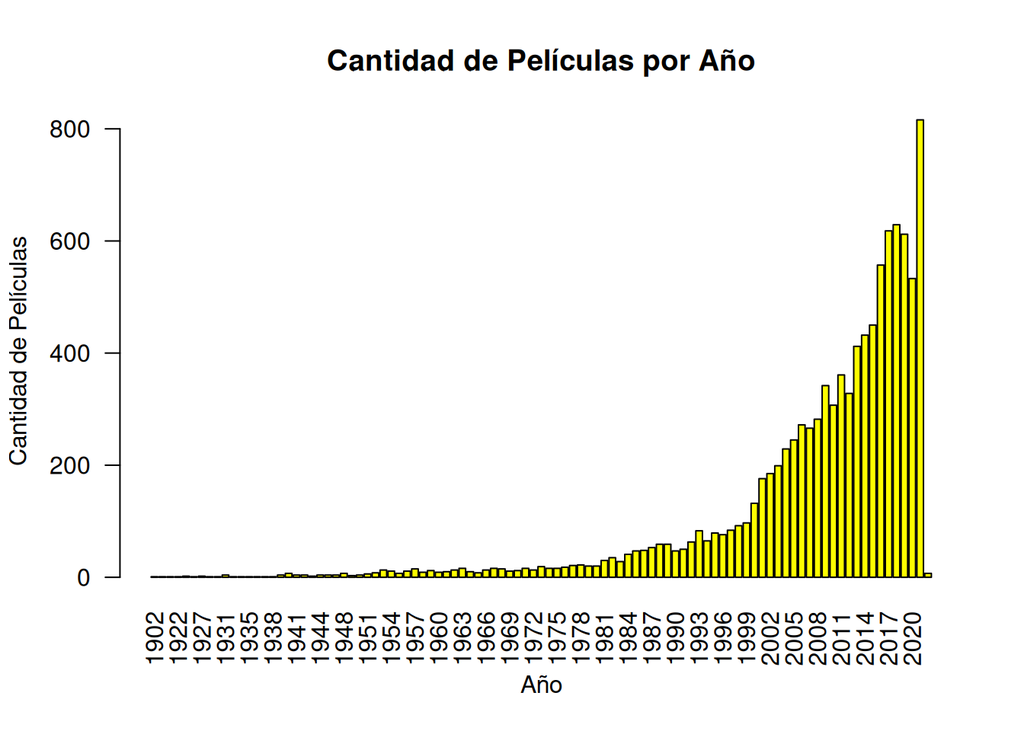

```r
movies$year <- as.numeric(substr(movies$releaseDate,1,4))
peliculas_año <- table(movies$year)

df_peliculas_año <- as.data.frame(peliculas_año)
colnames(df_peliculas_año) <-c("Año","Cantidad")

df_peliculas_año <- df_peliculas_año[order(df_peliculas_año$Año),]

barplot(df_peliculas_año$Cantidad,
        names.arg = df_peliculas_año$Año,
        main = "Cantidad de Películas por Año",
        xlab = "Año",
        ylab = "Cantidad de Películas",
        las = 2,
        col = "yellow")
```

Se puede observar que la cantidad de películas tiene una tendencia positiva conforme pasan los años. Siendo 2021 el año con más películas lanzadas.

# 4.7 Género con mayor ganancia

```r
library(data.table)

cat("*** Género con mayor ganancia ***\n")
```

```
## *** Género con mayor ganancia ***
```

```r
setDT(movies)
movies[, revenue := as.numeric(revenue)]
movies[, genres := strsplit(genres, split = "|", fixed = TRUE)]
movie_genres <- movies[, .(GENRE = unlist(genres), REVENUE = revenue)]
```

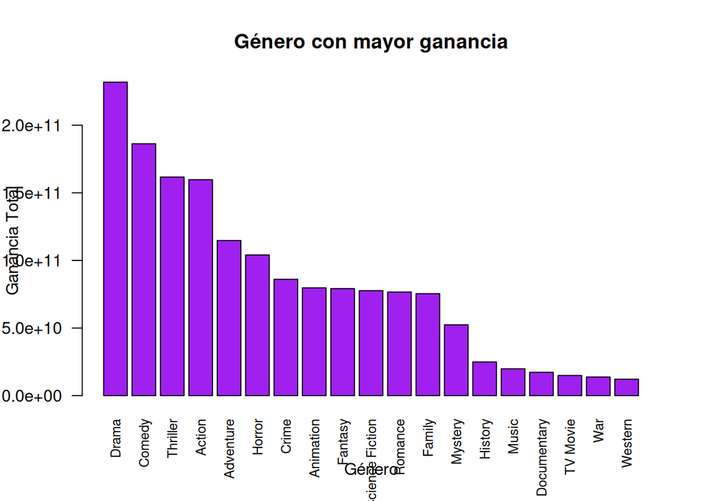

```r
movie_genres <- movie_genres[, .(TOTAL_REVENUE = sum(REVENUE, na.rm = TRUE)), by = GENRE]

movie_genres <- movie_genres[order(-TOTAL_REVENUE)]

barplot(setNames(movie_genres$TOTAL_REVENUE, movie_genres$GENRE),
        main = "Género con mayor ganancia",
        xlab = "Género",
        ylab = "Ganancia Total",
        las = 2,
        col = "purple",
        cex.names = 0.8)
```

```r
cat("El género con mayores ingresos es", movie_genres$GENRE[1],
    "con una ganancia total de $", format(movie_genres$TOTAL_REVENUE[1], big.mark = ","), ".\n")
```

```
## El género con mayores ingresos es Drama con una ganancia total de $ 231,815,065,756 .
```

# 4.9 Relacion entre la cantidad de hombres y mujeres y la popularidad/ingresos de las películas

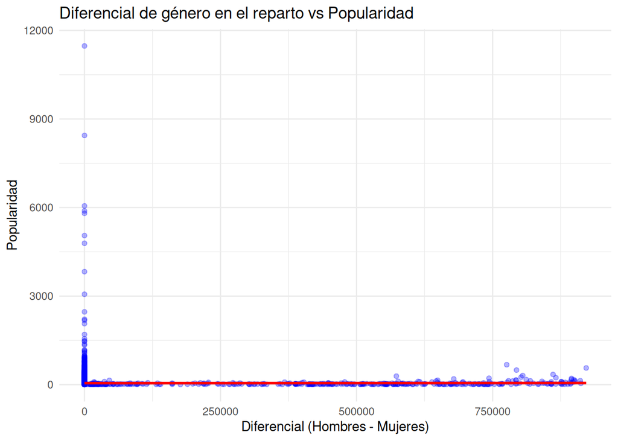

```r
library(ggplot2)
library(data.table)

setDT(movies)

movies[, revenue := as.numeric(revenue)]
movies[, popularity := as.numeric(popularity)]
movies[, castWomenAmount := as.numeric(castWomenAmount)]
movies[, castMenAmount := as.numeric(castMenAmount)]
movies[, diferencial := castMenAmount - castWomenAmount]

ggplot(movies, aes(x = diferencial, y = popularity)) +
  geom_point(alpha = 0.3, color = "blue") +
  geom_smooth(method = "lm", color = "red", se = FALSE) +
  labs(title = "Diferencial de género en el reparto vs Popularidad",
       x = "Diferencial (Hombres - Mujeres)",
       y = "Popularidad") +
  theme_minimal()
```

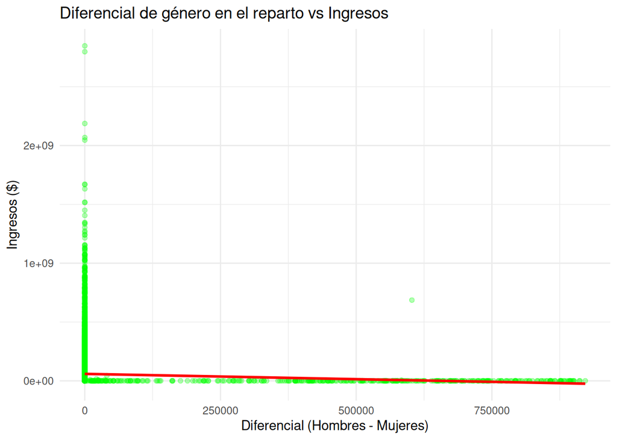

```r
ggplot(movies, aes(x = diferencial, y = revenue)) +
  geom_point(alpha = 0.3, color = "green") +
  geom_smooth(method = "lm", color = "red", se = FALSE) +
  labs(title = "Diferencial de género en el reparto vs Ingresos",
       x = "Diferencial (Hombres - Mujeres)",
       y = "Ingresos ($)") +
  theme_minimal()
```

```r
cor_popularity <- cor(movies$diferencial, movies$popularity, use = "complete.obs")
cor_revenue <- cor(movies$diferencial, movies$revenue, use = "complete.obs")

cat("*** Análisis de correlaciones ***\n")
```

```
## *** Análisis de correlaciones ***
```

```r
cat("Correlación entre diferencial de género y popularidad:", round(cor_popularity, 3), "\n")
```

```
## Correlación entre diferencial de género y popularidad: 0.003
```

```r
cat("Correlación entre diferencial de género e ingresos:", round(cor_revenue, 3), "\n")
```

```
## Correlación entre diferencial de género e ingresos: -0.06
```

La correlación entre el diferencial de género y popularidad de una película es de 0.003, prácticamente nulo; Esto indica que la cantidad de hombres y mujeres en el reparto no tiene impacto significativo en la popularidad de las películas.

Mientras que la correlación de género e ingresos es de -0.06, un poco más alto que la popularidad, pero aun es inferior a un 0.1 lo cual sugiere que no tiene impacto significativo en los ingresos.

# 4.11 Correlacion de presupuestos con ingresos

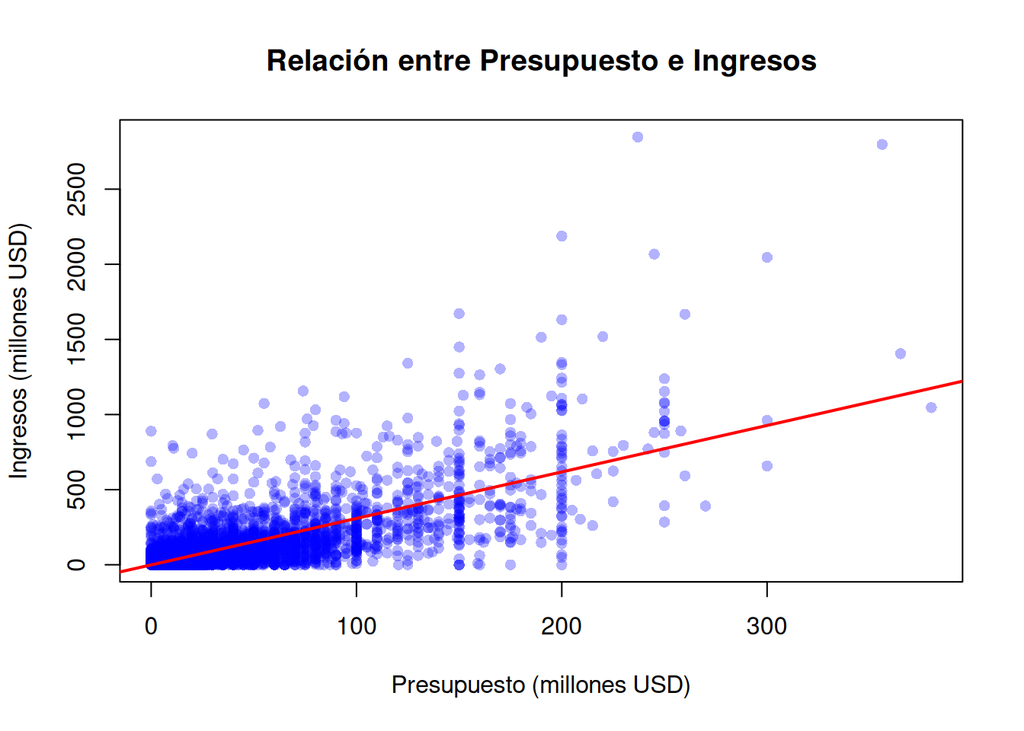

```r
correlacion <- cor(movies$budget, movies$revenue)

test_cor <- cor.test(movies$budget, movies$revenue)

movies$budget_M <- movies$budget/1e6
movies$revenue_M <- movies$revenue/1e6

# gráfico de dispersión
plot(movies$budget_M, movies$revenue_M,
     main = "Relación entre Presupuesto e Ingresos",
     xlab = "Presupuesto (millones USD)",
     ylab = "Ingresos (millones USD)",
     pch = 16,
     col = rgb(0, 0, 1, 0.3))

# línea de regresión
modelo <- lm(revenue_M ~ budget_M, data = movies)
abline(modelo, col = "red", lwd = 2)
```

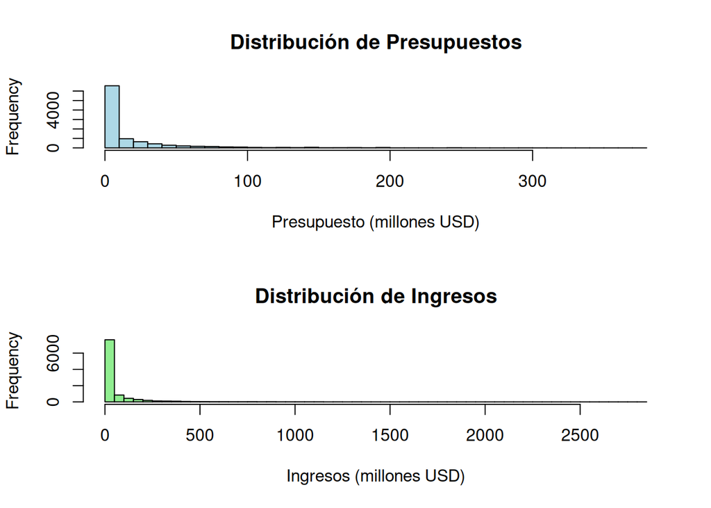

```r
# histogramas
par(mfrow = c(2, 1))

# histograma de presupuestos
hist(movies$budget_M,
     main = "Distribución de Presupuestos",
     xlab = "Presupuesto (millones USD)",
     col = "lightblue",
     breaks = 50)

# gistograma de ingresos
hist(movies$revenue_M,
     main = "Distribución de Ingresos",
     xlab = "Ingresos (millones USD)",
     col = "lightgreen",
     breaks = 50)
```

```r
par(mfrow = c(1, 1))

summary_stats <- data.frame(
    Estadística = c("Correlación", "P-valor", "R²"),
    Valor = c(correlacion,
              test_cor$p.value,
              summary(modelo)$r.squared)
)

cat("\n=== Análisis de Correlación entre Presupuesto e Ingresos ===\n")
```

```
##
## === Análisis de Correlación entre Presupuesto e Ingresos ===
```

```r
print(summary_stats)
```

```
##   Estadística     Valor
## 1 Correlación 0.7574540
## 2     P-valor 0.0000000
## 3          R² 0.5737366
```

```r
movies$roi <- ((movies$revenue - movies$budget) / movies$budget) * 100
movies$presupuesto_categoria <- cut(movies$budget_M,
                                  breaks = c(0, 10, 50, 100, Inf),
                                  labels = c("Bajo (<10M)",
                                           "Medio (10M-50M)",
                                           "Alto (50M-100M)",
                                           "Muy alto (>100M)"))

roi_por_categoria <- aggregate(roi ~ presupuesto_categoria,
                             data = movies,
                             FUN = function(x) mean(x, na.rm = TRUE))

cat("\n=== ROI Promedio por Categoría de Presupuesto ===\n")
```

```
##
## === ROI Promedio por Categoría de Presupuesto ===
```

```r
print(roi_por_categoria)
```

```
##   presupuesto_categoria       roi
## 1           Bajo (<10M) 1843.5960
## 2       Medio (10M-50M)  203.5196
## 3       Alto (50M-100M)  162.4756
## 4      Muy alto (>100M)  215.1654
```

La correlación entre presupuesto e ingresos es 0.757, indicando una relación fuerte y positiva. Esto sugiere que las películas con mayor presupuesto tienden a generar mayores ingresos. El valor p = 0.000 confirma que esta relación es significativa.

En cuanto al ROI promedio, las películas de bajo presupuesto (<10M) tienen un retorno sobresaliente de 1843.60%, mientras que las de presupuesto medio (10M-50M) y alto presupuesto (50M-100M) tienen retornos de 203.52% y 162.48%, respectivamente. Las de muy alto presupuesto (>100M) tienen un ROI de 215.17%, lo que sugiere que los grandes presupuestos no siempre generan los mejores retornos relativos.